# Structural equation models

Supplement 2 | PCB 6455 / BSC 4933: Biometry

Author

Dr. Brian Maitner

## This is optional

A supplement, not a lecture. Nothing here is due and nothing here is on an exam.

It assumes **Lectures 15 to 18**: likelihood, model comparison, AIC. It also uses a **generalized linear model**, which is Lectures 23 and 24. If you have not met GLMs yet, read `glm()` as “a regression for data that are not normal” and you will lose nothing.

**Every code block is meant to be run.** If it is on the page, you can paste it into R and get the output printed next to it.

This supplement does the whole method **by hand**, with `lm()`, `glm()` and about four lines of arithmetic. That is partly a teaching choice and partly forced on us, for a reason given at the end.

*Last checked: 2026-10-22, with R 4.4.1 and MASS 7.3-65.*

## The story so far

1. **A deterministic function** (Lectures 9 and 10): the shape you think the process has
2. **A distribution** (Lectures 11 and 12): the noise around that shape
3. **Likelihood** (Lecture 15): given parameters, how probable are the data you actually got
4. **Covariates** (Lecture 16): let a parameter change with something you measured
5. **Comparing models** (Lecture 18): the likelihood ratio test, and AIC when models are not nested
6. **GLMs** (Lectures 23 and 24): all of the above, packaged, for counts and proportions

. . .

7. **Today: more than one response.** Every piece above stays exactly as it is. The only new idea is that a variable can be a response in one equation and a predictor in the next.

If you are reading this alone, the thing to take from the list is that nothing new is being introduced. A structural equation model is a set of the models you already know how to fit, plus one test that is new.

Line 7 is the whole supplement in one sentence. Substrate is a response to slope, and a predictor of richness. No single regression can hold both roles at once, which is why we need a diagram.

## What you need

```r
install.packages("MASS")       # negative binomial regression
install.packages("remotes")

options(timeout = 600)
remotes::install_github("bmaitner/biometry_course",
                        subdir = "biometrydata",
                        upgrade = "never")
```

Then:

```r
library(MASS)
library(biometrydata)
```

That is the entire dependency list. No SEM package is involved, which is deliberate.

## The data

ROV video transects down a deep-sea margin: 749 subtransects, each with the physical conditions and a count of the animals seen.

```r
rov <- data.frame(
  depth    = tosca_rov$Depth.water..m.,
  temp     = tosca_rov$Temp....C.,
  sal      = tosca_rov$Sal,
  slope    = tosca_rov$Slope..deg.,
  hard     = as.integer(tosca_rov$Substrate %in% c("bedrock", "boulders")),
  richness = tosca_rov$S
)

rov <- rov[complete.cases(rov[, c("depth", "temp", "slope", "hard",
                                  "richness")]), ]
nrow(rov)
```

```
[1] 739
```

`?tosca_rov` gives the source and the original column names. The substrate classes are bedrock, boulders, gravel, biogenic gravels and sand. The first two are hard; the rest are not. Collapsing them is a judgment call, and it is the kind of judgment call worth stating out loud in a paper.

# Part 1: The question one regression cannot answer

## Two stories, one coefficient

Steeper seafloor holds more species. Fine. **Why?**

- **Story A.** Steep ground is harder to settle on, and the animals that cope with it are varied. Slope acts on richness directly.
- **Story B.** Steep ground sheds sediment and exposes bedrock. Hard surfaces are what sessile animals attach to. Slope acts on richness **through substrate**.

. . .

These are different claims about how the seafloor works, and they imply different things: under B, flatten the ground and you lose the species because you lost the rock.

A regression of richness on slope gives **the same coefficient either way**.

## What one regression says

```r
m_one <- glm.nb(richness ~ slope, data = rov)
round(summary(m_one)$coefficients, 5)
```

```
            Estimate Std. Error  z value Pr(>|z|)
(Intercept)  2.62510    0.05937 44.21782        0
slope        0.01271    0.00245  5.17990        0
```

Slope is strongly positive, and that is all you learn. The number is real and it answers a question nobody asked.

A single regression tells you that two things go together. It cannot tell you what happens in between.

## The variable in between

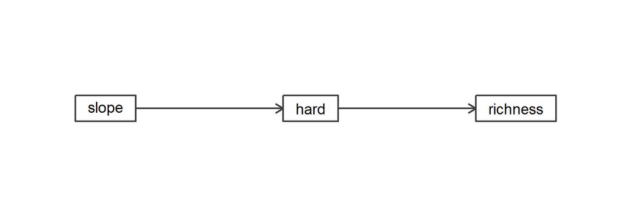

Substrate is the candidate. It is **caused by** slope and it **causes** richness, which means it is a response in one equation and a predictor in the next. No single regression holds both roles.

```r
tapply(rov$richness, rov$hard, mean)
```

```
       0        1
12.39252 22.47608
```

Hard substrate roughly doubles the count. So the middle box is not a technicality.

# Part 2: The diagram is the model

## What an arrow claims

An arrow from X to Y says: **if X changed and nothing else did, Y would change.** It is a claim about the mechanism, and it is a claim **you** are making. The data did not propose it.

. . .

Which means the arrows are the assumptions, written where a reader can see them. That is the real gain over a regression table, where the same assumptions are present but invisible.

Drawing the diagram does not discover the causes. It makes you write down what you already believe, so that someone can disagree with it.

## What a missing arrow claims

This is the part people skip, and it is where the statistics live.

- **An arrow** says a direct effect exists. You cannot test that by its absence.
- **A missing arrow** says a direct effect **does not** exist, once everything upstream is accounted for.

. . .

The second is the stronger claim, and the testable one. `slope -> hard -> richness` with no arrow straight from slope to richness says:

> once you know the substrate, slope tells you nothing more about richness.

That is a prediction. It can be checked, and it can be wrong.

If you take one thing from this supplement, take this slide.

Students routinely build a diagram with an arrow between every pair, because leaving an arrow out feels like an admission of ignorance. It is the opposite: the missing arrows are the content. A diagram with every arrow present predicts nothing and cannot be tested, and we will hit exactly that wall later on.

## Draw it before you fit it

The order matters, and it is the same discipline as writing the deterministic function down before fitting it in Lecture 9.

1. List the variables you measured
2. Draw the arrows you are willing to defend to a reviewer
3. **Notice which arrows you left out**, because those are your hypotheses
4. Fit, and test the ones you left out
5. Where the test disagrees with you, say so

We will do exactly that, and the test will disagree with us twice.

# Part 3: Path analysis by hand

## Two regressions, not one

Each box with an arrow coming in gets its own model. Here that is two.

```r
a <- lm(hard ~ slope, data = rov)              # slope -> hard
b <- lm(richness ~ hard + slope, data = rov)   # hard -> richness, slope direct

round(coef(a)["slope"], 5)
```

```
 slope
0.0076
```

```r
round(coef(b)[c("hard", "slope")], 5)
```

```
   hard   slope
9.02372 0.19526
```

`lm()` on a 0/1 response is wrong and we will fix it shortly. It is here because path arithmetic is clearer in straight lines, and because this is how path analysis was done for fifty years before anyone could fit a GLM.

## Direct, indirect, total

An indirect effect is a **product**: slope moves substrate, substrate moves richness, so slope moves richness by the two multiplied.

```r
indirect <- coef(a)["slope"] * coef(b)["hard"]
direct   <- coef(b)["slope"]

round(c(indirect = unname(indirect), direct = unname(direct),
        total = unname(indirect + direct)), 5)
```

```
indirect   direct    total
 0.06862  0.19526  0.26389
```

Multiply along a path to get what travels down it. Add the paths together to get the whole effect.

## The check that it is right

The total effect of slope should be exactly what a single regression of richness on slope gives, because that regression knows nothing about substrate and so reports everything slope does, by whatever route.

```r
round(coef(lm(richness ~ slope, data = rov))["slope"], 5)
```

```
  slope
0.26389
```

```r
round(indirect + direct, 5)
```

```
  slope
0.26389
```

. . .

Identical. That is not a coincidence and it is not an approximation: splitting a total effect into paths is an identity, not an estimate.

Use this as your check whenever you do this by hand. If the pieces do not sum to the total from the simple regression, you have the conditioning wrong, usually by putting a variable in the second model that does not belong there.

## Your turn: which route carries more?

The two numbers above are not comparable yet, because `slope` is in degrees and `hard` is 0 or 1. Standardizing puts every variable in standard deviations, so the paths can be compared.

```r
z <- function(x) (x - mean(x)) / sd(x)

rz <- transform(rov, slope = z(slope), hard = z(hard), richness = z(richness))

# refit the same two models on rz, then build the same two quantities
# (hint: you wrote both of them two slides ago)
az <- lm(hard ~ slope, data = rz)
bz <- lm(richness ~ hard + slope, data = rz)

round(c(indirect = unname(coef(az)["slope"] * coef(bz)["hard"]),
        direct   = unname(coef(bz)["slope"])), 3)
```

```
indirect   direct
   0.062    0.178
```

. . .

The direct path is about **three times** the indirect one. Substrate is a real route and a minority route: most of what slope does to richness, it does by some means we have not measured.

## What standardizing is for

Standardized coefficients answer “which arrow matters more”. Unstandardized ones answer “how much does richness change per degree of slope”. You need both, for different sentences.

Report unstandardized coefficients when the units mean something to a reader, which for depth in meters they do. Report standardized ones when you are comparing arrows, or drawing them at different widths.

Never compare raw coefficients across variables measured in different units. The arrow widths in half the SEM figures you will see are doing exactly that.

# Part 4: Piecewise SEM

## The idea, in one sentence

**Fit each response with the model you would have fitted anyway, then test the arrows you left out.**

That is the whole method. There is no joint likelihood, no new estimator, and nothing that needs a package. What makes it a structural equation model rather than a pile of regressions is the second half: the missing arrows get tested as a set.

The alternative tradition, covariance-based SEM, fits all the equations at once against the observed covariance matrix. It is a different culture with different software and different fit statistics, and the last section says where to find it. Piecewise is the one that fits what this course already teaches, and the one that copes with counts, binary outcomes and random effects.

## Choosing each component model

Each response gets the model its data type deserves. Richness is a count, so start with Poisson and check it.

```r
m_pois <- glm(richness ~ depth + slope + hard, family = poisson, data = rov)

round(deviance(m_pois) / df.residual(m_pois), 2)
```

```
[1] 9.49
```

That ratio should be near 1. It is near 10.

The counts vary far more than a Poisson allows. Using one anyway would make every p-value in the model far too small.

## The negative binomial, from Lecture 12

```r
m_rich <- glm.nb(richness ~ depth + slope + hard, data = rov)

round(deviance(m_rich) / df.residual(m_rich), 2)
```

```
[1] 1.17
```

```r
c(poisson = round(AIC(m_pois)), negbin = round(AIC(m_rich)))
```

```
poisson  negbin
  10098    5620
```

Ratio near 1, and AIC drops by thousands. This is the bestiary slide from Lecture 12 doing real work: the negative binomial is the count distribution with a spare parameter for extra variance, and deep-sea counts need it.

A reasonable worry: did switching distributions change the story? Compare the coefficients from the two fits. The estimates barely move; the standard errors roughly triple. That is the general pattern, and it is why ignoring overdispersion is dangerous rather than merely untidy. It does not usually invent an effect, it makes a real one look far more certain than it is.

## The diagram we will test

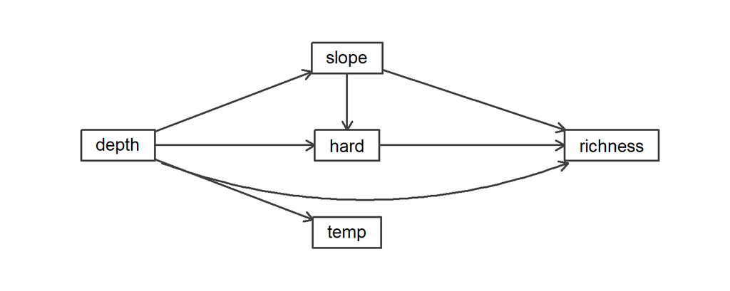

Depth drives everything physical. Slope and substrate act on richness, both directly and in sequence. Temperature is a consequence of depth **and nothing else**: no arrow runs from temperature to richness.

That last absence is the claim this diagram is making.

## The four component models

```r
m_temp  <- lm(temp ~ depth, data = rov)
m_slope <- lm(slope ~ depth, data = rov)
m_hard  <- glm(hard ~ depth + slope, family = binomial, data = rov)
m_rich  <- glm.nb(richness ~ depth + slope + hard, data = rov)
```

Four responses, four models, each one chosen for its own data type: two straight lines, a logistic regression for the 0/1 substrate, and a negative binomial for the counts.

Every one of these is a model you already know how to fit. Nothing above is new.

## Which absences get tested

List every pair of boxes with **no arrow between them**. For each, test whether they are still related once everything pointing into them is accounted for.

| Pair with no arrow | Account for | Does temperature still matter? |
| --- | --- | --- |
| temperature, slope | depth | ? |
| temperature, substrate | depth, slope | ? |
| temperature, richness | depth, slope, substrate | ? |

. . .

Three absences, three tests. Each one is a single `summary()` line: put the missing predictor into the model and look at its p-value.

This list has a name, the basis set, and a rule for building it: for each non-adjacent pair, condition on the parents of both. “Parents” means every box with an arrow pointing into them. You can build it by eye for a diagram this size, and you should, because doing it once is what makes the method stop feeling like magic.

## Testing the three absences

```r
p_of <- function(fit, term) {
  co <- summary(fit)$coefficients
  co[term, ncol(co)]                    # the p-value column
}

claims <- c(
  "temp vs slope"    = p_of(lm(slope ~ depth + temp, data = rov), "temp"),
  "temp vs hard"     = p_of(glm(hard ~ depth + slope + temp,
                                family = binomial, data = rov), "temp"),
  "temp vs richness" = p_of(glm.nb(richness ~ depth + slope + hard + temp,
                                   data = rov), "temp")
)
round(claims, 4)
```

```
   temp vs slope     temp vs hard temp vs richness
          0.0245           0.5071           0.6958
```

Two of the three absences are comfortable. The first is marginal: temperature and slope are not quite independent given depth.

## Fisher’s C: all three at once

A diagram stands or falls as a whole, so the three p-values are combined into one test.

```r
fisher_c <- function(p) {
  C  <- -2 * sum(log(p))
  df <- 2 * length(p)
  c(C = C, df = df, p = 1 - pchisq(C, df))
}

round(fisher_c(claims), 3)
```

```
    C    df     p
9.501 6.000 0.147
```

A small p-value here means the diagram is wrong: something you said was absent is plainly there. A large one means the data gave you no reason to add an arrow.

## Reading that the right way round

This is the reverse of every test in Lecture 18, and it catches people.

|  | Lecture 18’s tests | Fisher’s C |
| --- | --- | --- |
| Small p | the extra term earns its place | **your diagram is wrong** |
| Large p | no evidence for the extra term | **your diagram survives** |

Our C of 9.50 on 6 degrees of freedom gives **p = 0.147**. The diagram survives.

. . .

Writing it up honestly sounds like: “the hypothesized structure was consistent with the data (Fisher’s C = 9.50, df = 6, p = 0.15)”. Never “the model was confirmed” or, worse, “proven”.

The marginal first claim should be reported too. A reader who sees only the combined test cannot tell that one of the three absences was shaky, and that is the kind of thing that ought to be visible.

## The diagram that did not survive

Go back to Part 1 and take the strong version of Story B, where slope acts on richness **only** through substrate. One absence, so one claim.

```r
claim_strict <- c("slope vs richness" =
                    p_of(glm.nb(richness ~ hard + slope, data = rov), "slope"))

signif(claim_strict, 3)
```

```
slope vs richness
          1.4e-06
```

```r
signif(fisher_c(claim_strict), 3)
```

```
      C      df       p
2.7e+01 2.0e+00 1.4e-06
```

Rejected, decisively. Slope keeps a direct path to richness after substrate is accounted for, which is what the arithmetic in Part 3 already showed: the direct route was three times the indirect one.

Substrate is part of the story and not the whole story. The test is what tells you which of those two you are looking at.

# Part 5: A chain the data reject

## Temperature looks like the answer

The obvious deep-sea story: deeper water is colder, cold slows everything down, so richness falls with depth **because** of temperature.

```r
round(cor(rov$depth, rov$temp), 3)
```

```
[1] -0.644
```

```r
round(summary(glm.nb(richness ~ temp, data = rov))$coefficients, 5)
```

```
            Estimate Std. Error z value Pr(>|z|)
(Intercept)  1.56013    0.31829 4.90154    0e+00
temp         0.39167    0.09328 4.19900    3e-05
```

## Now put depth in

```r
round(summary(glm.nb(richness ~ temp + depth, data = rov))$coefficients, 5)
```

```
            Estimate Std. Error  z value Pr(>|z|)
(Intercept)  3.13893    0.53587  5.85757  0.00000
temp         0.09956    0.12150  0.81947  0.41252
depth       -0.00032    0.00009 -3.54978  0.00039
```

. . .

Temperature collapses to p = 0.41. Depth stands. Whatever depth is doing to these animals, it is not doing it by being cold.

Temperature looked important because it is a stand-in for depth. Put the real variable in and the stand-in has nothing left to explain.

## The same thing, as a d-separation test

The chain `depth -> temp -> richness` has one absence: no arrow from depth straight to richness.

```r
claim_temp <- c("depth vs richness" =
                  p_of(glm.nb(richness ~ temp + depth, data = rov), "depth"))

round(fisher_c(claim_temp), 5)
```

```
       C       df        p
15.72165  2.00000  0.00039
```

Rejected at p = 0.0004. Which is why, in the diagram we kept, temperature hangs off depth as a dead end and no arrow runs from it to richness.

Worth noticing how ordinary the test turned out to be. It is the same `glm.nb()` line, read for the p-value of the term you claimed was unnecessary. A d-sep test is not a new piece of statistics; it is a familiar piece pointed at the absences rather than the presences.

## What that episode is actually about

Nothing here was a mistake in the statistics. Each step was reasonable:

1. A plausible mechanism, from real biology
2. Both links individually strong
3. A conclusion that would have gone into a paper

The only thing that caught it was **fitting the whole diagram and testing what it left out**. One regression at a time cannot catch this, because one regression at a time is what produced it.

# Part 6: Comparing whole diagrams

## AIC, for diagrams

Lecture 18’s trade comes back unchanged: fit, against the number of parameters you spent. Shipley’s version uses Fisher’s C in place of the deviance.

$$\mathrm{AIC} = C + 2K$$

where $K$ counts every coefficient in every component model, plus the negative binomial’s extra variance parameter.

A diagram that explains its absences well, without using many parameters, wins. Same bargain as always.

## Is temperature worth an arrow?

Compare the diagram we kept against the same diagram with `temp -> richness` added. Adding it costs a parameter and removes one claim from the basis set.

```r
K_a <- length(coef(m_temp)) + length(coef(m_slope)) +
       length(coef(m_hard)) + length(coef(m_rich)) + 1   # +1 for theta

fc_a <- fisher_c(claims)                 # temperature a dead end
fc_b <- fisher_c(claims[1:2])            # temp -> richness added

round(c(A = unname(fc_a["C"]) + 2 * K_a,
        B = unname(fc_b["C"]) + 2 * (K_a + 1)), 2)
```

```
    A     B
33.50 34.78
```

. . .

A is lower, so the arrow does not pay for itself. But the gap is 1.27, and Lecture 18’s rule was that **within 2 is a tie**.

## When AIC will not decide

So AIC leans toward leaving temperature out and refuses to insist. Which is the honest answer: 739 subtransects cannot separate these two diagrams.

. . .

Report the tie. A reader who is told A won by 1.27 learns something false about how much the data knew.

# Part 7: Your turn

## Does salinity belong?

Salinity is in `rov` and has been ignored. Decide whether richness needs an arrow from it.

The absence to test is: **salinity and richness, accounting for everything already pointing into richness.**

```r
# 1. richness ~ salinity on its own. Is salinity related to richness at all?

# 2. now the claim: add sal to the richness component model, which already has
#    depth, slope and hard, and pull its p-value out with p_of()

# 3. run that one p-value through fisher_c(). Does the absence survive?
```

Work it before turning the page.

## The answer

```r
round(p_of(glm.nb(richness ~ sal, data = rov), "sal"), 4)
```

```
[1] 0.0978
```

```r
claim_sal <- c("sal vs richness" =
                 p_of(glm.nb(richness ~ depth + slope + hard + sal,
                             data = rov), "sal"))
round(fisher_c(claim_sal), 3)
```

```
    C    df     p
2.921 2.000 0.232
```

p = 0.23, so the absence survives: no arrow needed. On its own salinity was already borderline at 0.098, and conditioning finishes it off. Same shape as temperature, in a milder form.

. . .

A warning if you now want to draw salinity into the full diagram: salinity is tied hard to depth and slope, and adding the box brings **four new absences** with it. The whole diagram is then rejected, on claims that have nothing to do with richness. Every box you add is tested against every other.

# Part 8: What the arrows are not

## The arrows are assumptions you brought

The test checks whether the data are **consistent** with your diagram. It does not check whether the diagram is true, and nothing in this supplement licenses the word “causes” in a sentence about observational data.

. . .

The strongest honest claim from Part 4 is this: if slope, substrate and depth act the way we assumed, then what we see is unsurprising. Flip the arrows and much of it still fits.

A diagram that survives is a diagram the data could not knock down. That is a much weaker thing than a diagram the data support.

## Equivalent diagrams

Different diagrams can imply exactly the same absences, and then no amount of data separates them. `A -> B -> C` and `A <- B <- C` make the same single claim.

Ours has a real instance of this. Does slope expose bedrock, or does bedrock resist erosion and stay steep?

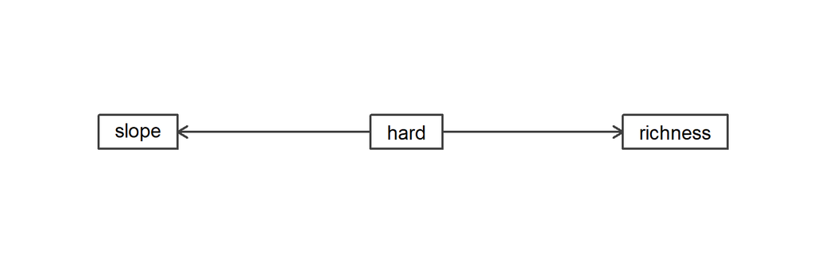

Geologically the second is at least as defensible. Statistically the two are indistinguishable here. The choice was made by argument, and it should be labeled as such in anything you write.

## The tautology trap

`rov` could have used Shannon diversity instead of richness. Both are in the file, and they correlate at 0.83, because one is computed from the other.

```r
round(cor(tosca_rov$S, tosca_rov$H., use = "complete.obs"), 3)
```

```
[1] 0.833
```

An arrow from richness to Shannon diversity would fit beautifully and mean nothing. It is arithmetic, not ecology.

Before you draw an arrow, check that the two boxes could in principle disagree. If one is calculated from the other, the arrow is guaranteed and worthless.

This failure is common and it is embarrassing in print. Watch for it with proportions and their denominators, indices and their components, biomass and abundance when biomass was derived from abundance, and anything per unit area regressed on area.

## These 739 rows are not 739 samples

```r
table(tosca_rov$Dive.no)
```

```
  5   6   7   8   9
169 159 166 131 124
```

Five dives. Subtransects within one dive share a site, a day, an operator and a camera, so they are nothing like independent, and every p-value in this supplement is more confident than it has any right to be.

The fix is a random effect for dive, which piecewise SEM does support. Five groups is too few to estimate one well, so the honest move here is to say so rather than to patch it.

This is why the supplement never claims an effect is “significant” without context. The point of the analysis is the structure, and the structure is unusually robust to this, since the comparison between substrate types happens within dives as well as between them. The exact p-values are not robust to it at all.

## Confounders you did not measure

Every missing-arrow test conditions on **the variables in your diagram**. A cause of both substrate and richness that nobody measured, such as current speed or food supply, is invisible to the whole procedure and will not show up in Fisher’s C.

. . .

This is the limit of the method, and it is not a small one. It is also why “consistent with the data” is the strongest phrase available: the data can rule diagrams out, and can never rule the missing variable in.

# Part 9: Where this goes next

## Latent variables, which we did not do

Every box here was something measured with an instrument. The other SEM tradition allows boxes for things you **cannot** measure, estimated from several indicators at once: “habitat quality” from substrate, rugosity and current; “condition” from three morphometrics.

That is a genuinely different tool, and it brings its own apparatus: a measurement model per latent variable, identification rules, and global fit indices.

It also wants several hundred observations per latent variable and indicators chosen in advance, which is why it belongs in a different module and not at the end of this one.

## The package, and why this was done by hand

`piecewiseSEM` automates everything in Part 4: it builds the basis set, runs the claims and prints Fisher’s C.

Not a type-and-run block, for the reason directly below it:

```r
# needs R 4.5.0 or newer
library(piecewiseSEM)

mod <- psem(
  lm(temp ~ depth, data = rov),
  lm(slope ~ depth, data = rov),
  glm(hard ~ depth + slope, family = binomial, data = rov),
  glm.nb(richness ~ depth + slope + hard, data = rov),
  data = rov
)
summary(mod)
```

As of October 2026 the CRAN version declares **R (>= 4.5.0)**, and this course runs on 4.4.1, so `install.packages("piecewiseSEM")` here just reports that the package is unavailable. Older versions sit in the CRAN archive, but installing one means building its dependencies from source, which is a long detour for a convenience function.

## Which is not really a loss

The hand-built version is forty lines of code you can read, it runs on any R from the last decade, and it will not break when a package changes.

More to the point: the basis set is the method. A function that builds it for you is convenient once you know what it is building, and a black box before that.

. . .

When your R is new enough, use the package. You will know what its output means, which is the reason to do it the long way once.

# Taking it with you

## What this buys you

1. **Draw the diagram before fitting anything.** The arrows you leave out are the hypotheses.
2. **A variable can be a response and a predictor.** That is the only structural idea here.
3. **Multiply along a path, add across paths.** Check the pieces against the simple regression; they must agree exactly.
4. **Standardize before comparing arrows**, never before interpreting units.
5. **Each response gets the model its data deserve.** Counts that are overdispersed get a negative binomial, as in Lecture 12.
6. **Test the absences, as a set**, with Fisher’s C, and remember that a large p-value is the good outcome.
7. **A surviving diagram has not been proven.** Say “consistent with”.

## Which tool, when

| You want to know | Use | In plain words |
| --- | --- | --- |
| Does X relate to Y? | regression | do they move together |
| Does X act on Y **through** Z? | **path analysis** | split the effect into routes and compare them |
| Is my whole picture consistent? | **d-separation**, Fisher’s C | is anything I called absent plainly there |
| Which of two pictures? | **AIC**, $C + 2K$ | same trade as Lecture 18; within 2 is a tie |
| Is the picture true? | **not available** | no statistic does this |

## Where it fits

- **Your final project**, if your data are observational and multi-variable. This is the one place in the course where a question about mechanism is allowed, and a two-box mediation is usually enough.
- **Reading papers.** SEM figures are everywhere in ecology and most readers nod at them. You can now ask the two questions that matter: which arrows are missing, and was the fit statistic reported the right way round.
- **Lecture 24**, as a reason the GLM choices matter: a component model with the wrong family makes every claim in the diagram wrong at once.

## Going further

- **Shipley (2009)**, where the d-separation test comes from, and still the clearest statement of it: https://doi.org/10.1890/08-1034.1
- **Shipley (2013)**, the AIC for these models: https://doi.org/10.1890/12-0976.1
- **Lefcheck (2016)**, the `piecewiseSEM` paper: https://doi.org/10.1111/2041-210X.12512
- **`piecewiseSEM` book**, free online and the best worked examples: https://jslefche.github.io/sem_book/
- **Grace (2006)**, *Structural Equation Modeling and Natural Systems*, the ecology-facing book on the covariance-based tradition

. . .

If you want to try this on your own data, bring the diagram to office hours before you fit anything. The diagram is where these go wrong, and it is much cheaper to fix on paper.